# Tugas MPDW Pekan 6

Andhias Abdillah Ridho

2026-09-30

# Packages

```r
library(ggplot2)
library(tsibble)
library(tseries)
library(MASS)
library(forecast)
library(TSA)
library(TTR)
library(aTSA)
library(graphics)
```

# Data

```r
library(readxl)
data <- read_xlsx("C:\\Users\\LENOVO\\Downloads\\CPIAUCSL_PC1.xlsx")
data
```

```
## # A tibble: 180 × 2
##    observation_date    CPIAUCSL_PC1
##    <dttm>                     <dbl>
##  1 2008-01-01 00:00:00         4.29
##  2 2008-02-01 00:00:00         4.14
##  3 2008-03-01 00:00:00         3.97
##  4 2008-04-01 00:00:00         3.90
##  5 2008-05-01 00:00:00         4.09
##  6 2008-06-01 00:00:00         4.94
##  7 2008-07-01 00:00:00         5.50
##  8 2008-08-01 00:00:00         5.31
##  9 2008-09-01 00:00:00         4.95
## 10 2008-10-01 00:00:00         3.73
## # ℹ 170 more rows
```

```r
names(data)
```

```
## [1] "observation_date" "CPIAUCSL_PC1"
```

# Eksplorasi Data

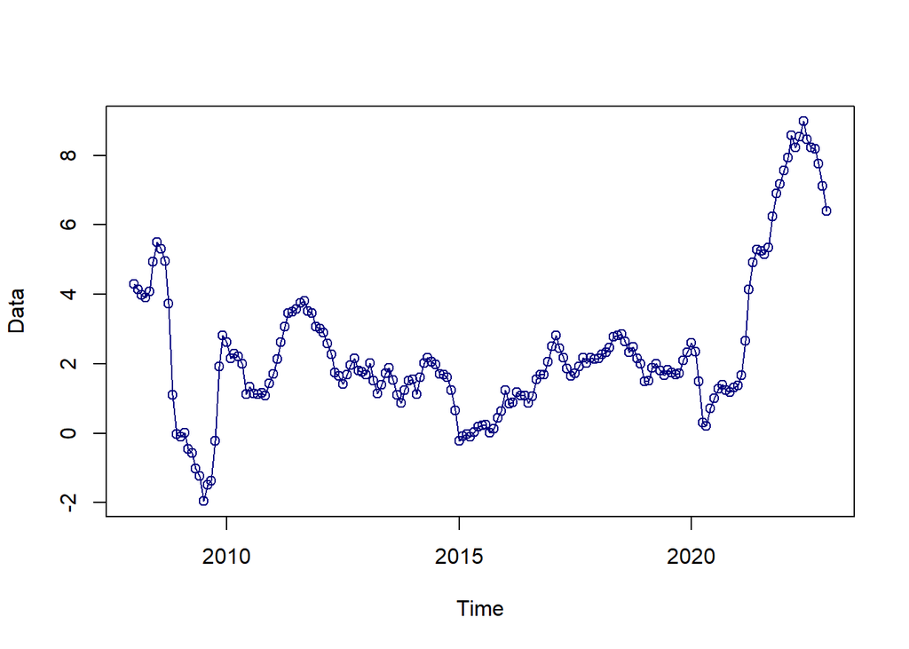

```r
#--PLOT TIME SERIES--#
plot(data,
     col = "navyblue",
     lwd = 1,
     type = "o",
     xlab = "Time",
     ylab = "Data")
```

Berdasarkan plot deret waktu, data belum menunjukkan pola yang jelas stasioner dalam rataan, karena terdapat perubahan level dari waktu ke waktu, terutama kenaikan yang cukup tajam pada periode akhir. Sementara itu, ragam data relatif cukup stabil, meskipun terdapat beberapa periode dengan fluktuasi yang lebih besar. Oleh karena itu, untuk memastikan kestasioneran data, selanjutnya dilakukan pemeriksaan menggunakan plot ACF dan uji Augmented Dickey-Fuller (ADF).

## Cek Stasioner

### Stasioner dalam rataan

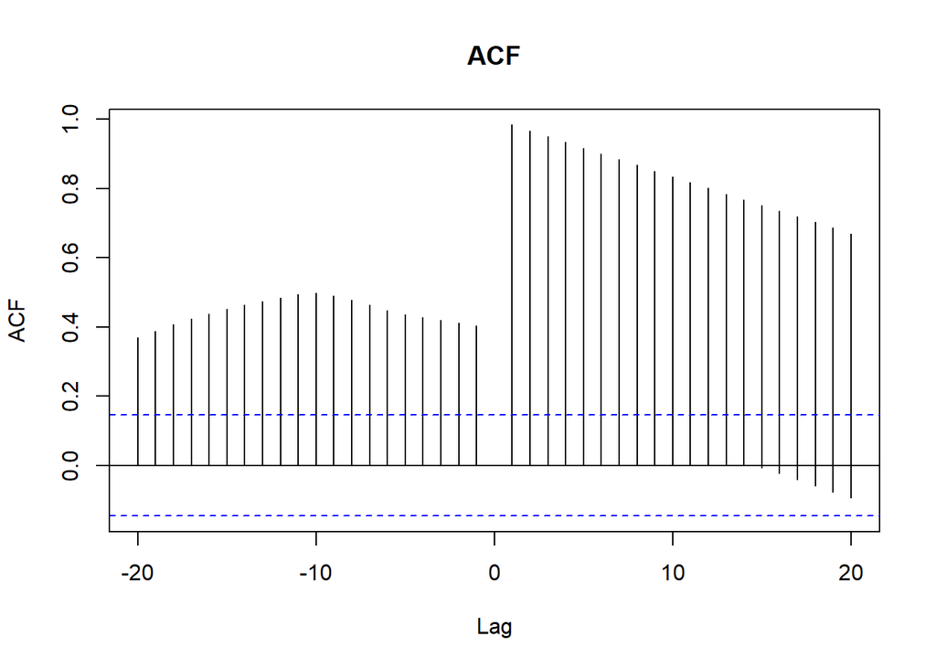

```r
#--CEK KESTASIONERAN---#
acf(data, main="ACF", lag.max=20)
```

Berdasarkan plot ACF di atas, terlihat bahwa nilai ACF menurun secara perlahan (tailing off) dan masih signifikan pada beberapa lag.

```r
adf.test(data$CPIAUCSL_PC1)
```

```
## Augmented Dickey-Fuller Test
## alternative: stationary
##
## Type 1: no drift no trend
##      lag    ADF p.value
## [1,]   0 -0.429  0.5205
## [2,]   1 -1.670  0.0918
## [3,]   2 -1.255  0.2293
## [4,]   3 -1.167  0.2607
## [5,]   4 -1.313  0.2084
## Type 2: with drift no trend
##      lag   ADF p.value
## [1,]   0 -1.01  0.6928
## [2,]   1 -2.67  0.0854
## [3,]   2 -2.16  0.2669
## [4,]   3 -2.07  0.3028
## [5,]   4 -2.26  0.2272
## Type 3: with drift and trend
##      lag   ADF p.value
## [1,]   0 -1.80  0.6560
## [2,]   1 -3.22  0.0857
## [3,]   2 -2.75  0.2602
## [4,]   3 -2.69  0.2879
## [5,]   4 -2.92  0.1931
## ----
## Note: in fact, p.value = 0.01 means p.value <= 0.01
```

Berdasarkan hasil uji Augmented Dickey-Fuller (ADF), diperoleh p-value lebih besar dari 0,05 pada seluruh spesifikasi model. Dengan demikian, H₀ tidak ditolak, sehingga dapat disimpulkan bahwa data belum stasioner dalam rataan. Hasil ini sejalan dengan plot ACF yang menunjukkan adanya autokorelasi yang masih cukup kuat pada beberapa lag. Oleh karena itu, diperlukan differencing untuk memperoleh data yang stasioner.

### Stasioner dalam Ragam

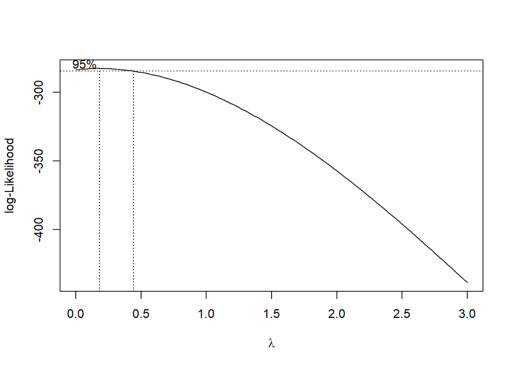

```r
# Data asli
x <- data$CPIAUCSL_PC1

# Menggeser data agar seluruh nilai > 0
shift <- abs(min(x, na.rm = TRUE)) + 1
x_shift <- x + shift

# Index
index <- seq(1:length(x_shift))

# Box-Cox
bc <- boxcox(
  x_shift ~ index,
  lambda = seq(0, 3, by = 1)
)
```

```r
# Nilai lambda optimum
lambda <- bc$x[which.max(bc$y)]
lambda
```

[output not shown]

```r
# Selang kepercayaan 95% untuk lambda
ci_lambda <- bc$x[
  bc$y > max(bc$y) - 0.5 * qchisq(0.95, 1)
]

# Batas bawah dan batas atas
ci_lower <- min(ci_lambda)
ci_upper <- max(ci_lambda)

c(
  Batas_Bawah = ci_lower,
  Batas_Atas = ci_upper
)
```

```
## Batas_Bawah  Batas_Atas
##   0.0000000   0.4242424
```

### Differencing

```r
#-- DIFFERENCING ORDE 1 --#
x_diff1 <- diff(data$CPIAUCSL_PC1, differences = 1)
```

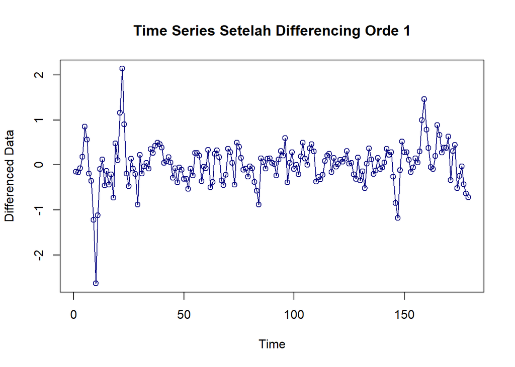

```r
plot(x_diff1,
     col = "navyblue",
     lwd = 1,
     type = "o",
     xlab = "Time",
     ylab = "Differenced Data",
     main = "Time Series Setelah Differencing Orde 1")
```

```r
adf.test(x_diff1)
```

```
## Augmented Dickey-Fuller Test
## alternative: stationary
##
## Type 1: no drift no trend
##      lag   ADF p.value
## [1,]   0 -7.16    0.01
## [2,]   1 -7.40    0.01
## [3,]   2 -6.68    0.01
## [4,]   3 -5.72    0.01
## [5,]   4 -5.46    0.01
## Type 2: with drift no trend
##      lag   ADF p.value
## [1,]   0 -7.14    0.01
## [2,]   1 -7.38    0.01
## [3,]   2 -6.66    0.01
## [4,]   3 -5.70    0.01
## [5,]   4 -5.43    0.01
## Type 3: with drift and trend
##      lag   ADF p.value
## [1,]   0 -7.16    0.01
## [2,]   1 -7.43    0.01
## [3,]   2 -6.73    0.01
## [4,]   3 -5.79    0.01
## [5,]   4 -5.62    0.01
## ----
## Note: in fact, p.value = 0.01 means p.value <= 0.01
```

H0: Data tidak stasioner dalam rataan H1: Data stasioner dalam rataan

Berdasarkan hasil uji Augmented Dickey-Fuller (ADF) setelah differencing orde 1, diperoleh p-value ≤ 0,01 pada seluruh spesifikasi model. Karena p-value < 0,05, maka H₀ ditolak. Dengan demikian, data telah stasioner setelah dilakukan differencing orde 1. Oleh karena itu, orde differencing yang digunakan adalah $d=1$.

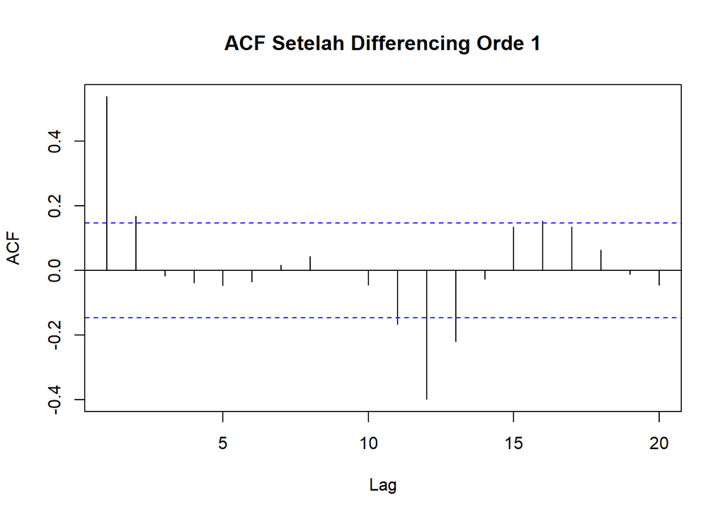

```r
acf(x_diff1,
    main = "ACF Setelah Differencing Orde 1",
    lag.max = 20)
```

Berdasarkan plot ACF setelah differencing orde 1, terdapat spike positif yang signifikan pada lag 1. Setelah lag 1, sebagian besar nilai ACF berada dalam batas signifikansi, meskipun terdapat beberapa spike signifikan pada lag yang lebih tinggi. Pola pada lag awal menunjukkan adanya komponen Moving Average (MA), dengan kandidat orde $q=1$.

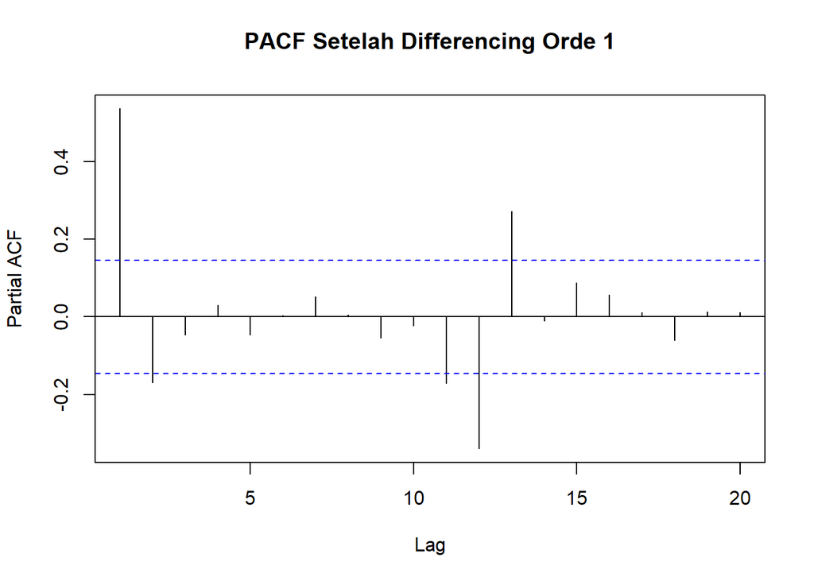

```r
pacf(x_diff1,
     main = "PACF Setelah Differencing Orde 1",
     lag.max = 20)
```

Berdasarkan plot PACF setelah differencing orde 1, terlihat bahwa terdapat spike yang melewati batas signifikansi pada lag 1 dan lag 2. Setelah lag tersebut, sebagian besar nilai PACF berada dalam batas signifikansi. Pola ini menunjukkan adanya komponen autoregressive (AR), dengan kandidat orde AR sebesar $p=2$.

Berdasarkan uji ADF tersebut, didapat p-value sebesar 0.01 yang lebih kecil dari taraf nyata 5% sehingga tolak H0 dan menandakan bahwa data stasioner dalam rataan.

# Spesifikasi Model

Setelah dilakukan differencing, data stasioner di differending orde 1 (d=1), lalu dilakukan plot ACF didapatkan terdapat spike positif yang signifikan pada lag 1. Kemudian, dilakukan plot PACF terlihat bahwa terdapat spike yang melewati batas signifikansi pada lag 1 dan lag 2.

```r
eacf(x_diff1)
```

```
## AR/MA
##   0 1 2 3 4 5 6 7 8 9 10 11 12 13
## 0 x x o o o o o o o o x  x  x  o
## 1 x x o o o o o o o o o  x  x  o
## 2 x o o o o o o o o o o  x  x  o
## 3 x o o o o o o o o o o  x  o  o
## 4 x x o o o o o o o o o  x  o  x
## 5 x x x o o o o o o o o  x  o  o
## 6 x x o o o o o o o o o  x  x  o
## 7 x x o o o o o o o o o  x  o  o
```

Berdasarkan hasil EACF, terdapat 9 kandidat ARIMA: ARIMA(0,1,0), ARIMA(0,1,1), ARIMA(0,1,2), ARIMA(1,1,0), ARIMA(1,1,1), ARIMA(1,1,2), ARIMA(2,1,0), ARIMA(2,1,1), ARIMA(2,1,2).

# Pendugaan Parameter

```r
#---PENDUGAAN PARAMETER MODEL---#
# ARIMA(0,1,0)
model_010 <- Arima(x, order = c(0,1,0), method = "ML")
summary(model_010)
```

```
## Series: x
## ARIMA(0,1,0)
##
## sigma^2 = 0.2204:  log likelihood = -118.63
## AIC=239.26   AICc=239.29   BIC=242.45
##
## Training set error measures:
##                      ME      RMSE       MAE      MPE     MAPE      MASE
## Training set 0.01174553 0.4681443 0.3200463 20.81803 80.57071 0.9945186
##                   ACF1
## Training set 0.5371534
```

```r
# ARIMA(0,1,1)
model_011 <- Arima(x, order = c(0,1,1), method = "ML")
summary(model_011)
```

```
## Series: x
## ARIMA(0,1,1)
##
## Coefficients:
##          ma1
##       0.5026
## s.e.  0.0537
##
## sigma^2 = 0.1615:  log likelihood = -90.45
## AIC=184.9   AICc=184.96   BIC=191.27
##
## Training set error measures:
##                       ME      RMSE       MAE       MPE     MAPE      MASE
## Training set 0.006931306 0.3996205 0.2823161 -0.206577 59.78609 0.8772749
##                   ACF1
## Training set 0.1208238
```

```r
# ARIMA(0,1,2)
model_012 <- Arima(x, order = c(0,1,2), method = "ML")
summary(model_012)
```

```
## Series: x
## ARIMA(0,1,2)
##
## Coefficients:
##          ma1     ma2
##       0.6233  0.2522
## s.e.  0.0712  0.0738
##
## sigma^2 = 0.1526:  log likelihood = -84.95
## AIC=175.9   AICc=176.04   BIC=185.46
##
## Training set error measures:
##                       ME      RMSE     MAE       MPE    MAPE     MASE
## Training set 0.005104951 0.3873987 0.27734 -25.31365 65.0845 0.861812
##                     ACF1
## Training set 0.006527686
```

```r
# ARIMA(1,1,0)
model_110 <- Arima(x, order = c(1,1,0), method = "ML")
summary(model_110)
```

```
## Series: x
## ARIMA(1,1,0)
##
## Coefficients:
##          ar1
##       0.5421
## s.e.  0.0629
##
## sigma^2 = 0.1567:  log likelihood = -87.76
## AIC=179.52   AICc=179.59   BIC=185.9
##
## Training set error measures:
##                       ME      RMSE       MAE       MPE     MAPE      MASE
## Training set 0.003363382 0.3936055 0.2810219 -14.10864 66.91663 0.8732534
##                    ACF1
## Training set 0.09247843
```

```r
# ARIMA(1,1,1)
model_111 <- Arima(x, order = c(1,1,1), method = "ML")
summary(model_111)
```

```
## Series: x
## ARIMA(1,1,1)
##
## Coefficients:
##          ar1     ma1
##       0.3842  0.2329
## s.e.  0.1107  0.1104
##
## sigma^2 = 0.1541:  log likelihood = -85.78
## AIC=177.55   AICc=177.69   BIC=187.12
##
## Training set error measures:
##                      ME      RMSE       MAE       MPE     MAPE      MASE
## Training set 0.00432323 0.3892225 0.2778327 -15.67049 64.33392 0.8633432
##                    ACF1
## Training set 0.01169435
```

```r
# ARIMA(1,1,2)
model_112 <- Arima(x, order = c(1,1,2), method = "ML")
summary(model_112)
```

```
## Series: x
## ARIMA(1,1,2)
##
## Coefficients:
##          ar1     ma1     ma2
##       0.0476  0.5793  0.2300
## s.e.  0.2769  0.2679  0.1528
##
## sigma^2 = 0.1535:  log likelihood = -84.94
## AIC=177.87   AICc=178.1   BIC=190.62
##
## Training set error measures:
##                       ME      RMSE       MAE       MPE     MAPE      MASE
## Training set 0.004990294 0.3873647 0.2774238 -25.21546 64.77098 0.8620726
##                     ACF1
## Training set 0.003123682
```

```r
# ARIMA(2,1,0)
model_210 <- Arima(x, order = c(2,1,0), method = "ML")
summary(model_210)
```

```
## Series: x
## ARIMA(2,1,0)
##
## Coefficients:
##          ar1      ar2
##       0.6313  -0.1666
## s.e.  0.0736   0.0739
##
## sigma^2 = 0.1532:  log likelihood = -85.26
## AIC=176.51   AICc=176.65   BIC=186.07
##
## Training set error measures:
##                       ME      RMSE       MAE       MPE     MAPE      MASE
## Training set 0.005106646 0.3880745 0.2767155 -20.25605 58.94988 0.8598714
##                      ACF1
## Training set -0.004450087
```

```r
# ARIMA(2,1,1)
model_211 <- Arima(x, order = c(2,1,1), method = "ML")
summary(model_211)
```

```
## Series: x
## ARIMA(2,1,1)
##
## Coefficients:
##          ar1      ar2      ma1
##       0.8361  -0.2783  -0.2106
## s.e.  0.3755   0.2032   0.3877
##
## sigma^2 = 0.1538:  log likelihood = -85.11
## AIC=178.23   AICc=178.46   BIC=190.98
##
## Training set error measures:
##                      ME      RMSE       MAE       MPE     MAPE      MASE
## Training set 0.00565317 0.3877639 0.2776207 -23.96944 63.19854 0.8626845
##                     ACF1
## Training set 0.001780238
```

```r
# ARIMA(2,1,2)
model_212 <- Arima(x, order = c(2,1,2), method = "ML")
summary(model_212)
```

```
## Series: x
## ARIMA(2,1,2)
##
## Coefficients:
##          ar1      ar2     ma1     ma2
##       0.1143  -0.0389  0.5128  0.2244
## s.e.  0.5520   0.2557  0.5471  0.1792
##
## sigma^2 = 0.1543:  log likelihood = -84.92
## AIC=179.85   AICc=180.2   BIC=195.79
##
## Training set error measures:
##                       ME      RMSE      MAE       MPE    MAPE      MASE
## Training set 0.005118222 0.3873398 0.277249 -25.76338 65.6256 0.8615294
##                     ACF1
## Training set 0.002962345
```

```r
hasil_model <- data.frame(
  Model = c(
    "ARIMA(0,1,0)",
    "ARIMA(0,1,1)",
    "ARIMA(0,1,2)",
    "ARIMA(1,1,0)",
    "ARIMA(1,1,1)",
    "ARIMA(1,1,2)",
    "ARIMA(2,1,0)",
    "ARIMA(2,1,1)",
    "ARIMA(2,1,2)"
  ),
  AIC = c(
    AIC(model_010),
    AIC(model_011),
    AIC(model_012),
    AIC(model_110),
    AIC(model_111),
    AIC(model_112),
    AIC(model_210),
    AIC(model_211),
    AIC(model_212)
  ),
  BIC = c(
    BIC(model_010),
    BIC(model_011),
    BIC(model_012),
    BIC(model_110),
    BIC(model_111),
    BIC(model_112),
    BIC(model_210),
    BIC(model_211),
    BIC(model_212)
  )
)

hasil_model
```

```
##          Model      AIC      BIC
## 1 ARIMA(0,1,0) 239.2627 242.4501
## 2 ARIMA(0,1,1) 184.8964 191.2711
## 3 ARIMA(0,1,2) 175.9015 185.4637
## 4 ARIMA(1,1,0) 179.5236 185.8984
## 5 ARIMA(1,1,1) 177.5537 187.1158
## 6 ARIMA(1,1,2) 177.8712 190.6208
## 7 ARIMA(2,1,0) 176.5122 186.0743
## 8 ARIMA(2,1,1) 178.2300 190.9795
## 9 ARIMA(2,1,2) 179.8492 195.7861
```

Berdasarkan perbandingan nilai AIC dan BIC, model ARIMA(0,1,2) memiliki nilai AIC dan BIC terendah, masing-masing sebesar 175,9015 dan 185,4637. Oleh karena itu, ARIMA(0,1,2) dipilih sebagai kandidat model berdasarkan kriteria informasi. Selanjutnya, model perlu dilakukan pemeriksaan diagnostik residual untuk memastikan residual telah memenuhi asumsi white noise.

# Analisis Sisaan

## Eksplorasi Sisaan

```r
models <- list(
  "ARIMA(0,1,0)" = model_010,
  "ARIMA(0,1,1)" = model_011,
  "ARIMA(0,1,2)" = model_012,
  "ARIMA(1,1,0)" = model_110,
  "ARIMA(1,1,1)" = model_111,
  "ARIMA(1,1,2)" = model_112,
  "ARIMA(2,1,0)" = model_210,
  "ARIMA(2,1,1)" = model_211,
  "ARIMA(2,1,2)" = model_212
)
```

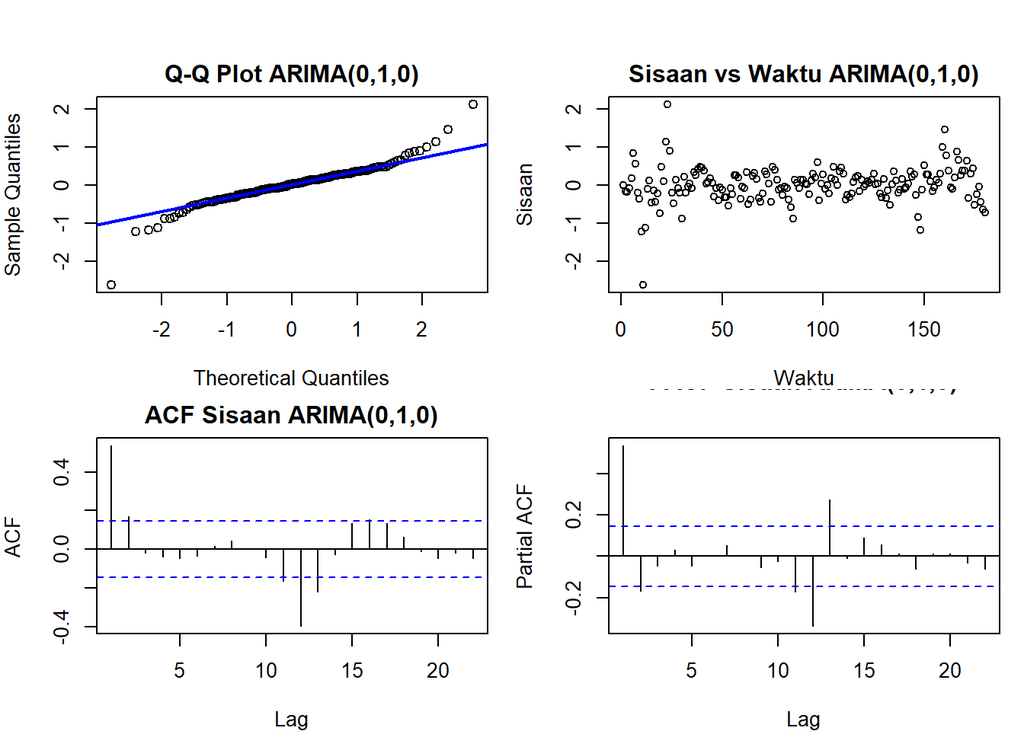

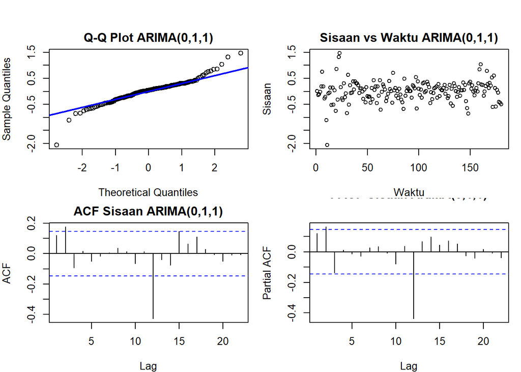

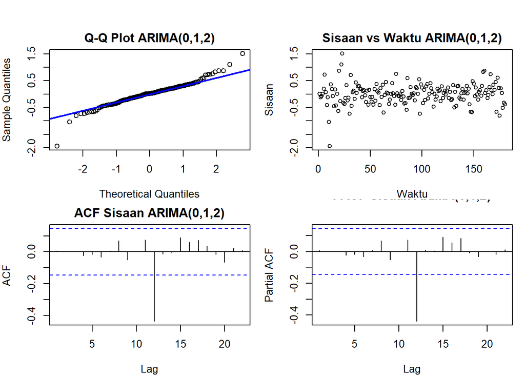

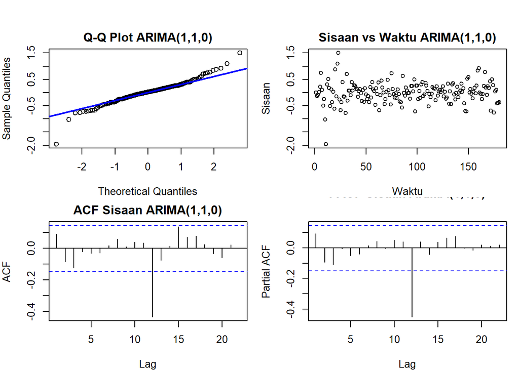

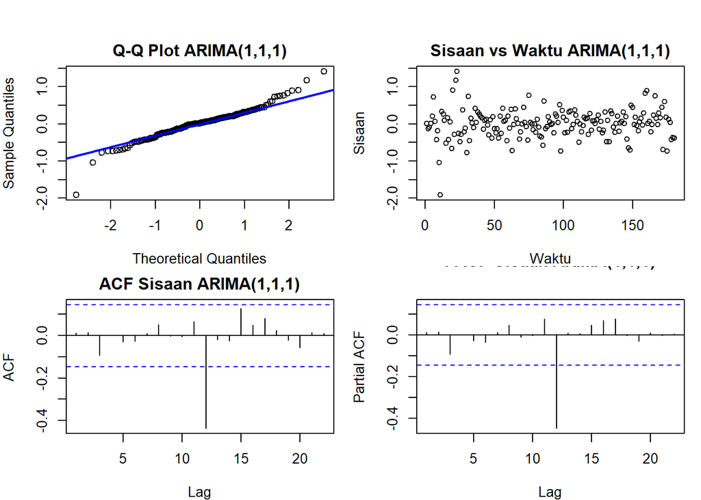

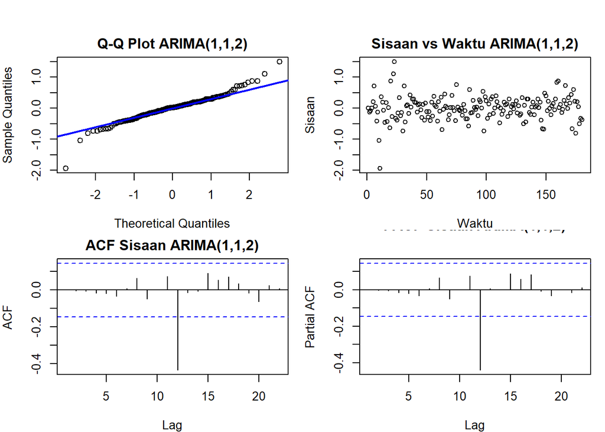

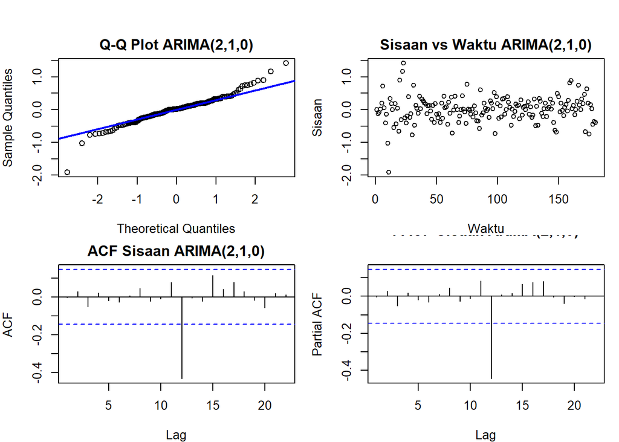

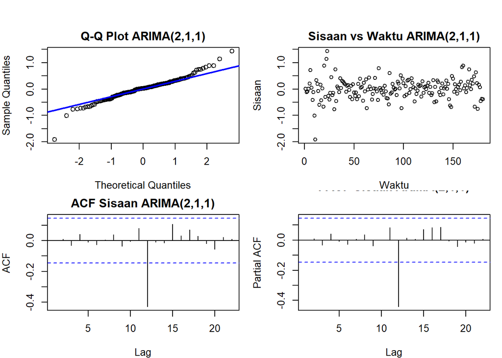

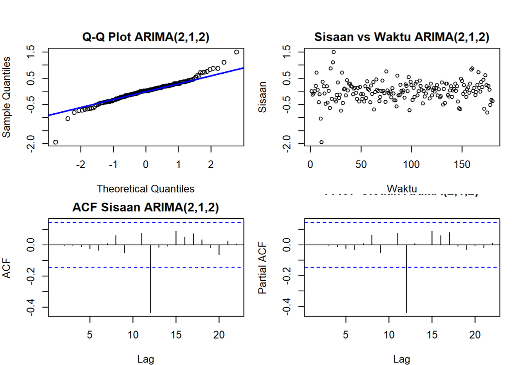

```r
for (nama in names(models)) {

  sisaan <- residuals(models[[nama]])

  par(mfrow = c(2,2),
      mar = c(4,4,2,1),
      oma = c(0,0,2,0))

  qqnorm(sisaan, main = paste("Q-Q Plot", nama))
  qqline(sisaan, col = "blue", lwd = 2)

  plot(sisaan, type = "p",
       main = paste("Sisaan vs Waktu", nama),
       xlab = "Waktu", ylab = "Sisaan")

  acf(sisaan, main = paste("ACF Sisaan", nama))

  pacf(sisaan, main = paste("PACF Sisaan", nama))
}
```

## Uji Formal

```r
hasil_uji <- data.frame()

for (nama in names(models)) {

  sisaan <- residuals(models[[nama]])

  # Uji normalitas
  ks <- ks.test(sisaan, "pnorm")

  # Uji autokorelasi
  lb <- Box.test(
    sisaan,
    lag = 12,
    type = "Ljung-Box"
  )

  # Uji homogenitas ragam
  lb2 <- Box.test(
    sisaan^2,
    lag = 12,
    type = "Ljung-Box"
  )

  # Uji rata-rata residual = 0
  tt <- t.test(
    sisaan,
    mu = 0,
    conf.level = 0.95
  )

  hasil_uji <- rbind(
    hasil_uji,
    data.frame(
      Model = nama,
      KS_pvalue = ks$p.value,
      LjungBox_pvalue = lb$p.value,
      LjungBox_Sq_pvalue = lb2$p.value,
      Ttest_pvalue = tt$p.value
    )
  )
}

hasil_uji$Normal <- ifelse(
  hasil_uji$KS_pvalue > 0.05,
  "Terpenuhi",
  "Tidak terpenuhi"
)

hasil_uji$Independen <- ifelse(
  hasil_uji$LjungBox_pvalue > 0.05,
  "Terpenuhi",
  "Tidak terpenuhi"
)

hasil_uji$Homogen <- ifelse(
  hasil_uji$LjungBox_Sq_pvalue > 0.05,
  "Terpenuhi",
  "Tidak terpenuhi"
)

hasil_uji$Mean_0 <- ifelse(
  hasil_uji$Ttest_pvalue > 0.05,
  "Terpenuhi",
  "Tidak terpenuhi"
)

hasil_uji
```

```
##          Model    KS_pvalue LjungBox_pvalue LjungBox_Sq_pvalue Ttest_pvalue
## 1 ARIMA(0,1,0) 2.641314e-09    3.330669e-15       3.517137e-09    0.7374293
## 2 ARIMA(0,1,1) 2.267833e-11    3.741916e-06       2.213583e-07    0.8167321
## 3 ARIMA(0,1,2) 1.466886e-10    8.163092e-05       2.373107e-07    0.8602432
## 4 ARIMA(1,1,0) 7.693528e-10    1.200359e-05       9.938845e-07    0.9091049
## 5 ARIMA(1,1,1) 1.728429e-10    5.360098e-05       1.635896e-07    0.8820244
## 6 ARIMA(1,1,2) 1.492955e-10    8.394424e-05       2.338488e-07    0.8633392
## 7 ARIMA(2,1,0) 5.835960e-11    8.976565e-05       1.886389e-07    0.8604382
## 8 ARIMA(2,1,1) 2.439261e-10    1.324279e-04       3.702214e-07    0.8455570
## 9 ARIMA(2,1,2) 1.344867e-10    8.722687e-05       2.650473e-07    0.8598625
##            Normal      Independen         Homogen    Mean_0
## 1 Tidak terpenuhi Tidak terpenuhi Tidak terpenuhi Terpenuhi
## 2 Tidak terpenuhi Tidak terpenuhi Tidak terpenuhi Terpenuhi
## 3 Tidak terpenuhi Tidak terpenuhi Tidak terpenuhi Terpenuhi
## 4 Tidak terpenuhi Tidak terpenuhi Tidak terpenuhi Terpenuhi
## 5 Tidak terpenuhi Tidak terpenuhi Tidak terpenuhi Terpenuhi
## 6 Tidak terpenuhi Tidak terpenuhi Tidak terpenuhi Terpenuhi
## 7 Tidak terpenuhi Tidak terpenuhi Tidak terpenuhi Terpenuhi
## 8 Tidak terpenuhi Tidak terpenuhi Tidak terpenuhi Terpenuhi
## 9 Tidak terpenuhi Tidak terpenuhi Tidak terpenuhi Terpenuhi
```